# Adult Census Income

Jadon Chu

11 Oct 2024

# Overview

We will work with the [Adult Census Income dataset](https://archive.ics.uci.edu/dataset/2/adult) to predict whether an individual earns more than $50K per year. This data was originally extracted from the [1994 Census bureau database](https://www.census.gov/en.html) and was donated to [UCI Machine Learning Data Repository](https://archive.ics.uci.edu/) for research and education purposes.

The [data repository website](https://archive.ics.uci.edu/dataset/2/adult) contains some attribute definitions of the corresponding data sets. Most of the descriptions are self-explanatory. For instance, `sex` represents the gender of a census respondent. However, some are not so intuitive and not included in text. Below is the **additional detailed descriptions** for those attributes.

- `fnlwgt`: a continuous numeric attribute meaning ‘Final Weight’. It indicates the number of people in the population that each record represents, calculated based on demographic characteristics such as age, gender, race, and geographic region. The U.S. Census Bureau uses this attribute to adjust for the survey sampling method to ensure that the data represents the actual population proportions.
- `education-num`: a continuous variable that assigns a number to each level of education, corresponding to the number of years of education an individual has completed.
- `capital-gain`’: a continuous numeric attribute (in US dollars), referring to income derived from selling assets (e.g., stocks, real estate) at a price higher than the purchase price.
- `capital-loss`: a continuous numeric attribute (in US dollars), referring to a loss incurred from selling assets at a lower price than the purchase price.
- `hours-per-week`: a continuous numeric attribute representing how many hours the person typically works each week, providing insight into their work schedule, whether part-time, full-time, or potentially over-time.

In this project, we will process the data, perform exploratory data analysis (EDA), and **build several binary classification models** using R.

```r
knitr::opts_chunk$set(echo = TRUE)

# Load libraries
library(tidyverse)
```

```r
library(ggplot2)
library(glmnet)
library(caret)
library(rpart)
library(ranger)
library(xgboost)
```

# 1. Data Exploration and Processing

### Loading the Data

We will exclude the attribute `nflwgt` as it is a weighting factor for the population, whereas our goal here is to predict the annul income level for each individual.

Loading the `adult.data` and assigning meaningful column names to the data frame: Note that the target response is `income`.

```r
url <- "https://archive.ics.uci.edu/ml/machine-learning-databases/adult/adult.data"

column_names <- c('age', 'workclass', 'fnlwgt', 'education', 'education_num', 'marital_status', 'occupation', 'relationship', 'race', 'sex', 'capital_gain', 'capital_loss', 'hours_per_week', 'native_country', 'income' )

data <- read_csv(url, col_names = column_names)
dim(data) # 15 columns
```

```
## [1] 32561    15
```

```r
# Remove the 'fnlwgt' column
data <- data[, -which(colnames(data) == "fnlwgt")]
dim(data) # 14 columns
```

```
## [1] 32561    14
```

```r
glimpse(data)
```

```
## Rows: 32,561
## Columns: 14
## $ age            <dbl> 39, 50, 38, 53, 28, 37, 49, 52, 31, 42, 37, 30, 23, 32,…
## $ workclass      <chr> "State-gov", "Self-emp-not-inc", "Private", "Private", …
## $ education      <chr> "Bachelors", "Bachelors", "HS-grad", "11th", "Bachelors…
## $ education_num  <dbl> 13, 13, 9, 7, 13, 14, 5, 9, 14, 13, 10, 13, 13, 12, 11,…
## $ marital_status <chr> "Never-married", "Married-civ-spouse", "Divorced", "Mar…
## $ occupation     <chr> "Adm-clerical", "Exec-managerial", "Handlers-cleaners",…
## $ relationship   <chr> "Not-in-family", "Husband", "Not-in-family", "Husband",…
## $ race           <chr> "White", "White", "White", "Black", "Black", "White", "…
## $ sex            <chr> "Male", "Male", "Male", "Male", "Female", "Female", "Fe…
## $ capital_gain   <dbl> 2174, 0, 0, 0, 0, 0, 0, 0, 14084, 5178, 0, 0, 0, 0, 0, …
## $ capital_loss   <dbl> 0, 0, 0, 0, 0, 0, 0, 0, 0, 0, 0, 0, 0, 0, 0, 0, 0, 0, 0…
## $ hours_per_week <dbl> 40, 13, 40, 40, 40, 40, 16, 45, 50, 40, 80, 40, 30, 50,…
## $ native_country <chr> "United-States", "United-States", "United-States", "Uni…
## $ income         <chr> "<=50K", "<=50K", "<=50K", "<=50K", "<=50K", "<=50K", "…
```

Note: it was found that the category ‘Holand-Netherlands’ only has one observation in the data, and the ‘adult.test’ data set does not contain any observations from this category.

```r
data |> group_by(native_country) |> summarise(n_obs = n()) |> ungroup() |> arrange(n_obs)
```

```
## # A tibble: 42 × 2
##    native_country             n_obs
##    <chr>                      <int>
##  1 Holand-Netherlands             1
##  2 Scotland                      12
##  3 Honduras                      13
##  4 Hungary                       13
##  5 Outlying-US(Guam-USVI-etc)    14
##  6 Yugoslavia                    16
##  7 Laos                          18
##  8 Thailand                      18
##  9 Cambodia                      19
## 10 Trinadad&Tobago               19
## # ℹ 32 more rows
```

To prevent issues when applying our models to the test dataset, we will remove this observation:

```r
data <- data |>
  mutate(across(where(is.character), ~ str_trim(.)))  %>% # remove white-space
  filter(!native_country == 'Holand-Netherlands')
```

This ensures consistency between the training and test data.

### Addressing Missing Values

What percentage of the data records contains missing values?

```r
# First set-up
sum(is.na(data)) # NAs? No. But e.g. native-country should have missing values, are they marked as '?'?
```

```
## [1] 0
```

```r
data |> pull(`native_country`) |> unique() # Yes, turn them to NAs for easier handling
```

```
##  [1] "United-States"              "Cuba"
##  [3] "Jamaica"                    "India"
##  [5] "?"                          "Mexico"
##  [7] "South"                      "Puerto-Rico"
##  [9] "Honduras"                   "England"
## [11] "Canada"                     "Germany"
## [13] "Iran"                       "Philippines"
## [15] "Italy"                      "Poland"
## [17] "Columbia"                   "Cambodia"
## [19] "Thailand"                   "Ecuador"
## [21] "Laos"                       "Taiwan"
## [23] "Haiti"                      "Portugal"
## [25] "Dominican-Republic"         "El-Salvador"
## [27] "France"                     "Guatemala"
## [29] "China"                      "Japan"
## [31] "Yugoslavia"                 "Peru"
## [33] "Outlying-US(Guam-USVI-etc)" "Scotland"
## [35] "Trinadad&Tobago"            "Greece"
## [37] "Nicaragua"                  "Vietnam"
## [39] "Hong"                       "Ireland"
## [41] "Hungary"
```

```r
data[data== '?'] <- NA
sum(is.na(data)) # 4262 NAs
```

```
## [1] 4262
```

```r
# Calculate % of data records with missing data:
missing_percentage <- sum(!complete.cases(data)) / nrow(data) * 100
missing_percentage # 7.37%
```

```
## [1] 7.367936
```

The percentage of records with missing values is 7.37% (relatively small).

Comparing the proportions of missingness for each income class:

```r
missingness_proportions <- data |>
  mutate(has_missing = !complete.cases(data)) |>
  group_by(income) |>
  count(has_missing)
missingness_proportions
```

```
## # A tibble: 4 × 3
## # Groups:   income [2]
##   income has_missing     n
##   <chr>  <lgl>       <int>
## 1 <=50K  FALSE       22653
## 2 <=50K  TRUE         2066
## 3 >50K   FALSE        7508
## 4 >50K   TRUE          333
```

Note that the majority of records in the data set belong to the `<=50k` class:

```r
data |>
  group_by(income) |>
  count()
```

```
## # A tibble: 2 × 2
## # Groups:   income [2]
##   income     n
##   <chr>  <int>
## 1 <=50K  24719
## 2 >50K    7841
```

The number of records in the data set belonging to the `<=50k` class is over 3 times that of the `>50k` class. So the data set is imbalanced.

**Removing the Missing Data**

Removing the missing values in this case is justifiable because they constitute a relatively small proportion of both income classes, so their removal is unlikely to introduce significant bias or distort the overall distribution of the data. Additionally, it helps simplifies the analysis by avoiding the need for imputation methods, which could introduce additional assumptions and potential errors.

Removing just 2399 rows:

```r
data_clean <- na.omit(data)
```

Converting the response into a binary group for classification further on.

```r
data_clean$income <- ifelse(data_clean$income == '<=50K', 0, 1)
data_clean$income <- as.factor(data_clean$income)
glimpse(data_clean)
```

```
## Rows: 30,161
## Columns: 14
## $ age            <dbl> 39, 50, 38, 53, 28, 37, 49, 52, 31, 42, 37, 30, 23, 32,…
## $ workclass      <chr> "State-gov", "Self-emp-not-inc", "Private", "Private", …
## $ education      <chr> "Bachelors", "Bachelors", "HS-grad", "11th", "Bachelors…
## $ education_num  <dbl> 13, 13, 9, 7, 13, 14, 5, 9, 14, 13, 10, 13, 13, 12, 4, …
## $ marital_status <chr> "Never-married", "Married-civ-spouse", "Divorced", "Mar…
## $ occupation     <chr> "Adm-clerical", "Exec-managerial", "Handlers-cleaners",…
## $ relationship   <chr> "Not-in-family", "Husband", "Not-in-family", "Husband",…
## $ race           <chr> "White", "White", "White", "Black", "Black", "White", "…
## $ sex            <chr> "Male", "Male", "Male", "Male", "Female", "Female", "Fe…
## $ capital_gain   <dbl> 2174, 0, 0, 0, 0, 0, 0, 0, 14084, 5178, 0, 0, 0, 0, 0, …
## $ capital_loss   <dbl> 0, 0, 0, 0, 0, 0, 0, 0, 0, 0, 0, 0, 0, 0, 0, 0, 0, 0, 0…
## $ hours_per_week <dbl> 40, 13, 40, 40, 40, 40, 16, 45, 50, 40, 80, 40, 30, 50,…
## $ native_country <chr> "United-States", "United-States", "United-States", "Uni…
## $ income         <fct> 0, 0, 0, 0, 0, 0, 0, 1, 1, 1, 1, 1, 0, 0, 0, 0, 0, 0, 1…
```

### Exploring the Data

Looking at the distribution of the target response `income`:

```r
income_summary <- data_clean |>
  group_by(income) |>
  count()
income_summary
```

```
## # A tibble: 2 × 2
## # Groups:   income [2]
##   income     n
##   <fct>  <int>
## 1 0      22653
## 2 1       7508
```

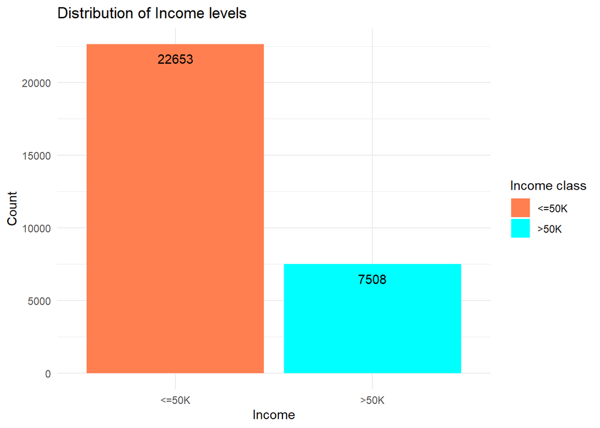

```r
ggplot(income_summary, aes(x=factor(income), y = n, fill=factor(income))) +
  geom_col() +
  scale_x_discrete(labels = c('<=50K', '>50K')) +
  labs(title = "Distribution of Income levels", x = "Income", y = "Count",
       fill= "Income class") +
  geom_text(aes(label=n),
            position=position_nudge(y=-1000)) +
  theme_minimal() +
  scale_fill_manual(values=c("coral", "cyan"), labels = c("<=50K", ">50K"))
```

With missing values removed, the data set is imbalanced with the number of records belonging to the `<=50K` class being 3 times more than that of the `>50K` class in the data set, as observed before.

Exploring some of the variables that may be related to income:

1. `education` (Education level)

Higher education levels are generally correlated to higher paying jobs.

2. `hours_per_week` (Hours worked per week)

It makes sense that individuals who work longer hours per week are likely to earn higher incomes.

3. `occupation`

Different occupations tend to have different salary ranges. For example, professional jobs or management roles tend to be higher paying than service jobs.

Exploring their relationships with income:

**Education Level vs Income**

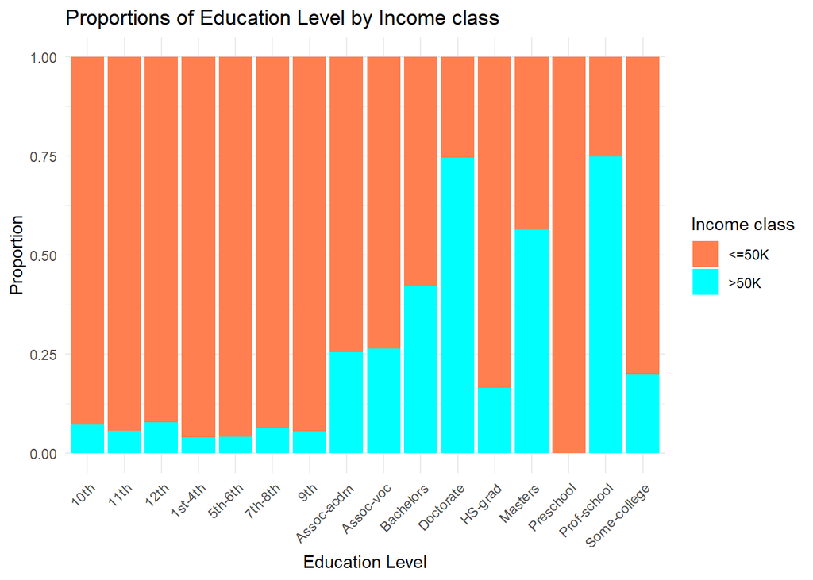

```r
# Education Level vs Income
ggplot(data_clean, aes(x = education, fill = factor(income))) +
  geom_bar(position = "fill") +
  labs(title = "Proportions of Education Level by Income class", x = "Education Level", y = "Proportion", fill = "Income class") +
  scale_fill_manual(values = c("coral", "cyan"), labels = c("<=50K", ">50K")) +
  theme_minimal() +
  theme(axis.text.x = element_text(angle = 45, hjust = 1))  # rotate x-axis labels
```

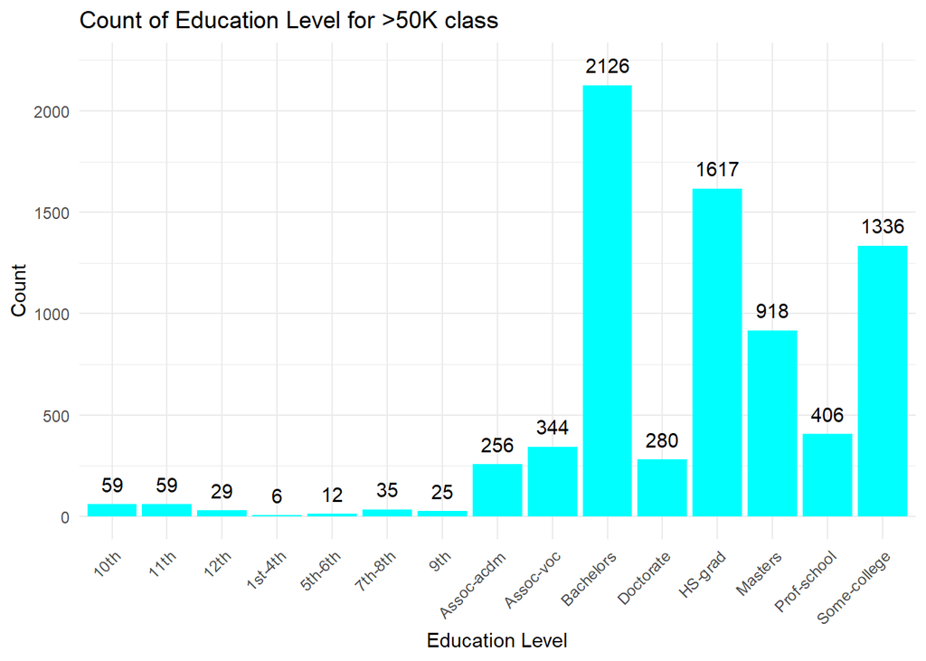

```r
### Look at the number of Education Level for each class separately
num_edu_over <- data_clean |>
  filter(income == 1) |>
  group_by(education) |>
  count()

# Show column chart for >50K
num_edu_over |>
  ggplot(aes(x=education, y=n)) +
  geom_col(fill="cyan") +
  geom_text(aes(label=n),
            position=position_nudge(y= 100)) +
  theme_minimal() +
  theme(axis.text.x = element_text(angle = 45, hjust = 1)) +
  labs(title="Count of Education Level for >50K class", x="Education Level", y="Count")
```

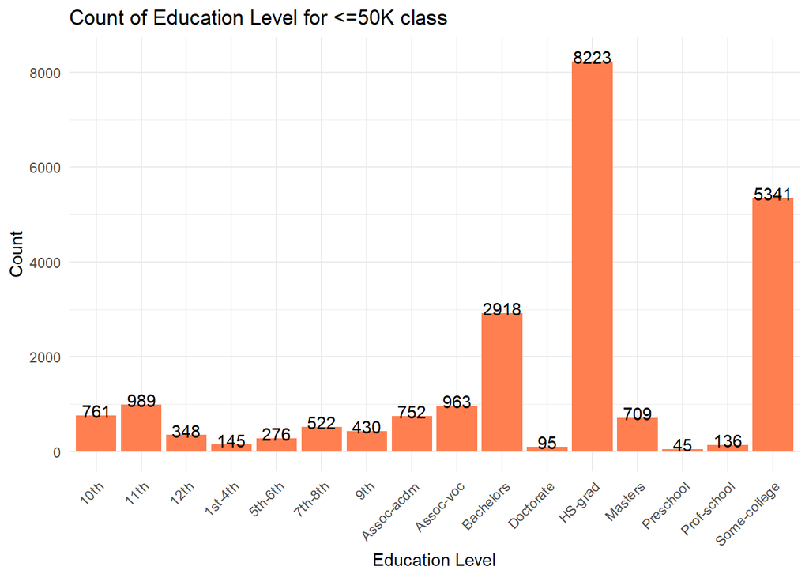

```r
# Counts of occupations for <=50K
num_edu_under <- data_clean |>
  filter(income == 0) |>
  group_by(education) |>
  count()

# Show column chart for <=50K
num_edu_under |>
  ggplot(aes(x=education, y=n)) +
  geom_col(fill="coral") +
  geom_text(aes(label=n),
            position=position_nudge(y= 100)) +
  theme_minimal() +
  theme(axis.text.x = element_text(angle = 45, hjust = 1)) +
  labs(title="Count of Education Level for <=50K class", x="Education Level", y="Count")
```

We will remove the `education_num` attribute, as it is redundant. Instead, we will retain the `education` attribute, which captures the broader educational categories relevant to income.

```r
# Remove the 'education_num' attribute
dim(data_clean) # expect 14 cols
```

```
## [1] 30161    14
```

```r
data_clean <- data_clean[, -which(colnames(data_clean) == "education_num")]
dim(data_clean) # expect 13 cols
```

```
## [1] 30161    13
```

**Hours per week vs Income**

Let’s first look at the distribution, then compare between the two classes.

```r
# First, checking the range of values for Hours per week
range(data_clean$hours_per_week) # It is unusual for an individual to work 99 hours
```

```
## [1]  1 99
```

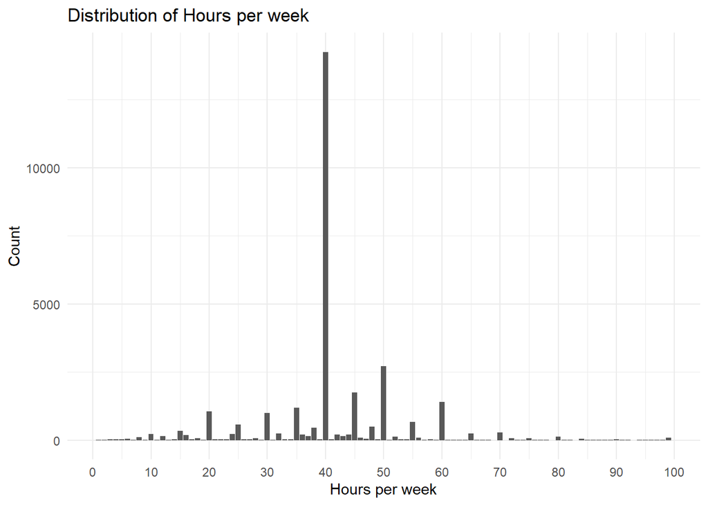

```r
hpw_summary <- data_clean |>
  group_by(hours_per_week) |>
  count()

# Distribution of Hours per week
hpw_summary |>
  ggplot(aes(x=hours_per_week, y=n)) +
  geom_col() +
  labs(title="Distribution of Hours per week", x="Hours per week", y="Count") +
  theme_minimal() +
  scale_x_continuous(breaks=seq(0, 100, 10))
```

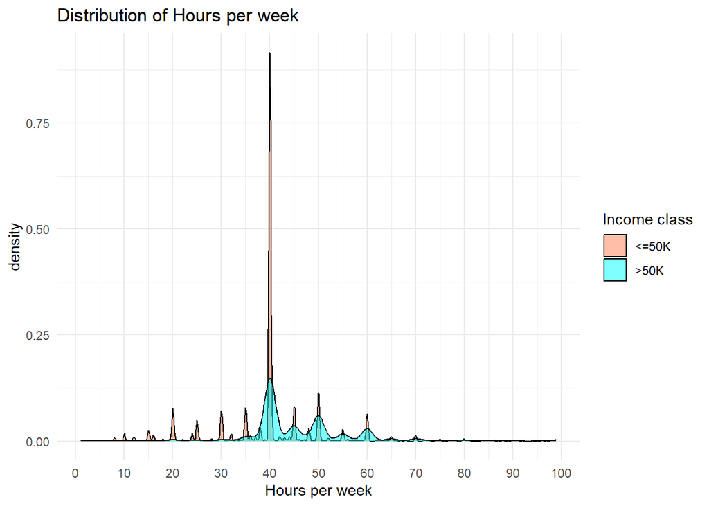

```r
# Comparing between the two groups using a Density plot
data_clean |>
  ggplot() +
  geom_density(aes(x=hours_per_week,
                   fill = factor(income)),
               alpha=0.5) +
  theme_minimal() +
  scale_fill_manual(values=c("coral", "cyan"), labels = c("<=50K", ">50K")) +
  labs(title = "Distribution of Hours per week", x="Hours per week", fill="Income class") +
  scale_x_continuous(breaks=seq(0, 100, 10))
```

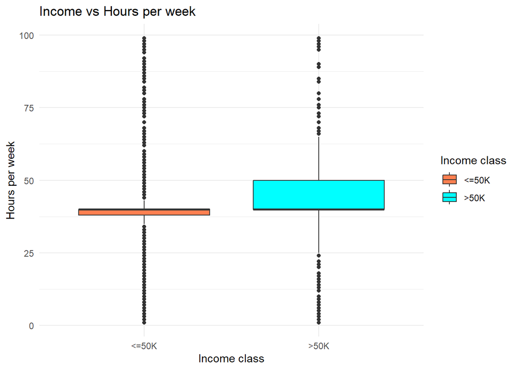

```r
# Comparing between the two groups with a Box plot
ggplot(data_clean, aes(x=factor(income), y=hours_per_week, fill=factor(income))) +
  geom_boxplot() +
  labs(title="Income vs Hours per week", x="Income class", y="Hours per week",
       fill="Income class") +
  theme_minimal() +
  scale_x_discrete(labels = c('<=50K', '>50K')) +
  scale_fill_manual(values=c("coral", "cyan"), labels = c("<=50K", ">50K"))
```

**Occupation vs Income**

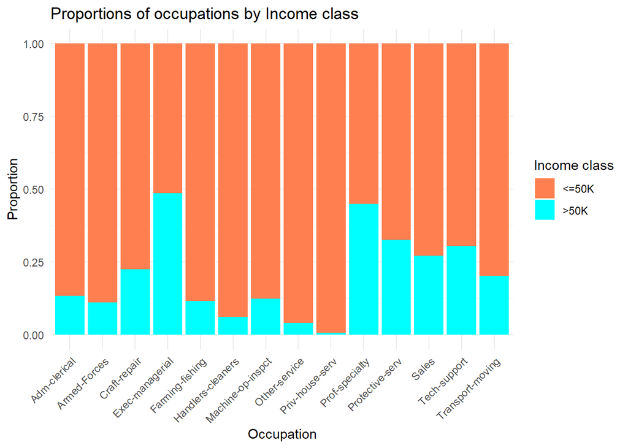

```r
# Occupation vs Income
ggplot(data_clean, aes(x = occupation, fill = factor(income))) +
  geom_bar(position = "fill") +
  labs(title = "Proportions of occupations by Income class", x = "Occupation", y = "Proportion", fill = "Income class") +
  scale_fill_manual(values = c("coral", "cyan"), labels = c("<=50K", ">50K")) +
  theme_minimal() +
  theme(axis.text.x = element_text(angle = 45, hjust = 1))  # rotate x-axis labels
```

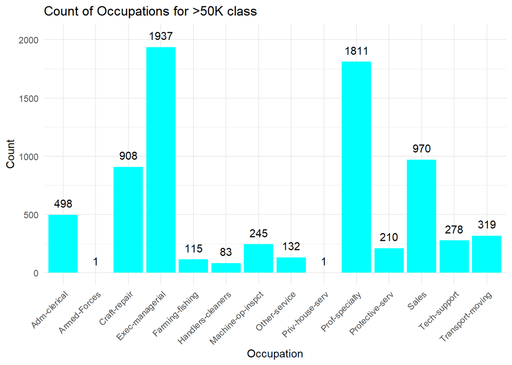

```r
### Look at the number of occupations for each class separately
num_occupations_over <- data_clean |>
  filter(income == 1) |>
  group_by(occupation) |>
  count()

# Show column chart for >50K
num_occupations_over |>
  ggplot(aes(x=occupation, y=n)) +
  geom_col(fill="cyan") +
  geom_text(aes(label=n),
            position=position_nudge(y= 100)) +
  theme_minimal() +
  theme(axis.text.x = element_text(angle = 45, hjust = 1)) +
  labs(title="Count of Occupations for >50K class", x="Occupation", y="Count")
```

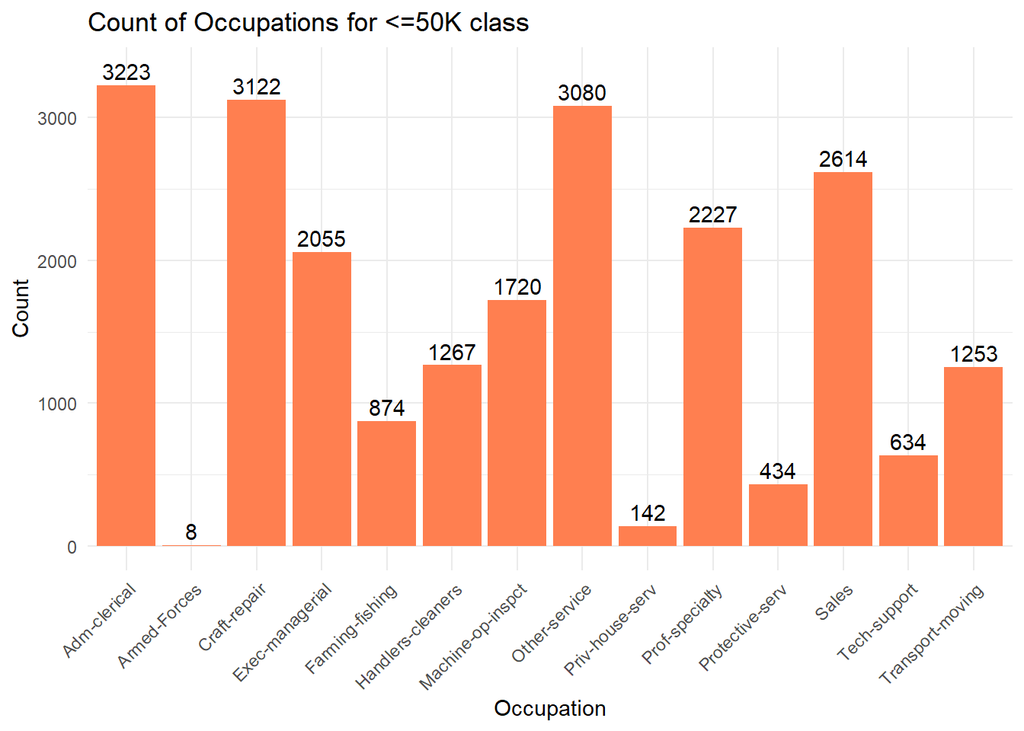

```r
# Counts of occupations for <=50K
num_occupations_under <- data_clean |>
  filter(income == 0) |>
  group_by(occupation) |>
  count()

# Show column chart for <=50K
num_occupations_under |>
  ggplot(aes(x=occupation, y=n)) +
  geom_col(fill="coral") +
  geom_text(aes(label=n),
            position=position_nudge(y= 100)) +
  theme_minimal() +
  theme(axis.text.x = element_text(angle = 45, hjust = 1)) +
  labs(title="Count of Occupations for <=50K class", x="Occupation", y="Count")
```

Of individuals who earn more than 50K, they are most likely to be in occupations like `Exec-managerial` or `Prof-specialty`, in-fact, their proportions are just about half with the `<=50K` class i.e. if an individual’s occupation are one of the two, then he/she is quite likely to earn more than 50K considering most people earn less than that. In contrast, occupations like `Handlers-cleaners`, `priv-house-serv`, and `other-service` are largely dominated by individuals earning less than 50K.

Let’s briefly look at the relationships of other variables with `income`:

**Age vs Income**

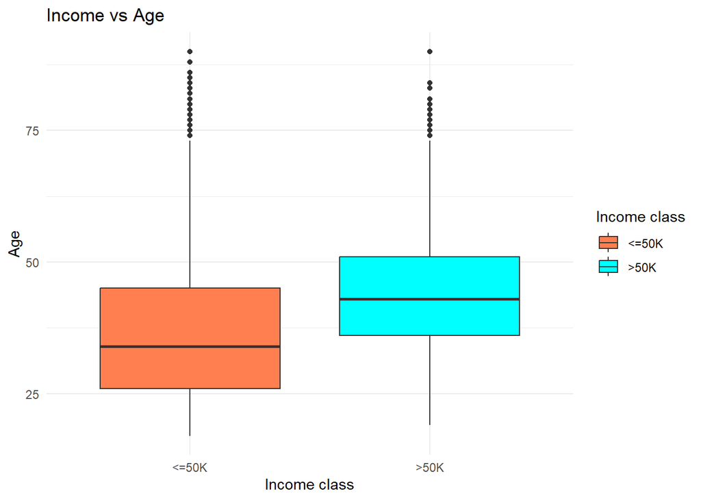

```r
# Age vs Income
ggplot(data_clean, aes(x=factor(income), y=age, fill=factor(income))) +
  geom_boxplot() +
  labs(title="Income vs Age", x="Income class", y="Age",
       fill="Income class") +
  theme_minimal() +
  scale_x_discrete(labels = c('<=50K', '>50K')) +
  scale_fill_manual(values=c("coral", "cyan"), labels = c("<=50K", ">50K"))
```

Age is positively correlated with income, this makes sense as individuals who are older tend to earn more.

**Gender vs Income**

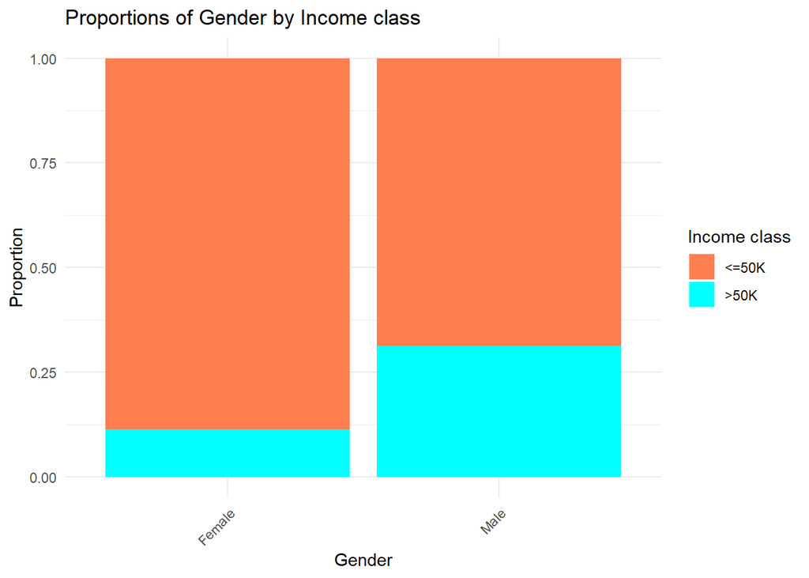

```r
# Gender vs Income
ggplot(data_clean, aes(x = sex, fill = factor(income))) +
  geom_bar(position = "fill") +
  labs(title = "Proportions of Gender by Income class", x = "Gender", y = "Proportion", fill = "Income class") +
  scale_fill_manual(values = c("coral", "cyan"), labels = c("<=50K", ">50K")) +
  theme_minimal() +
  theme(axis.text.x = element_text(angle = 45, hjust = 1))  # rotate x-axis labels
```

**Marital Status vs Income**

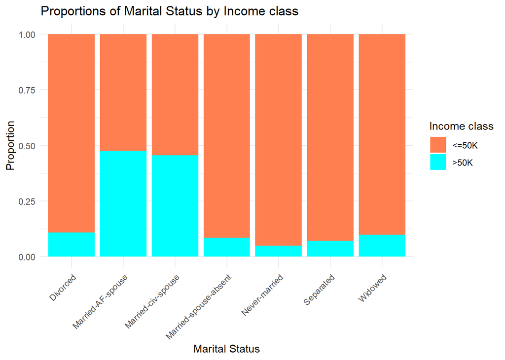

```r
# Marital status vs Income
ggplot(data_clean, aes(x = marital_status, fill = factor(income))) +
  geom_bar(position = "fill") +
  labs(title = "Proportions of Marital Status by Income class", x = "Marital Status", y = "Proportion", fill = "Income class") +
  scale_fill_manual(values = c("coral", "cyan"), labels = c("<=50K", ">50K")) +
  theme_minimal() +
  theme(axis.text.x = element_text(angle = 45, hjust = 1))  # rotate x-axis labels
```

Gender and marital status show potential disparities in income, as men and married individuals are more likely to earn higher incomes.

**Race vs Income**

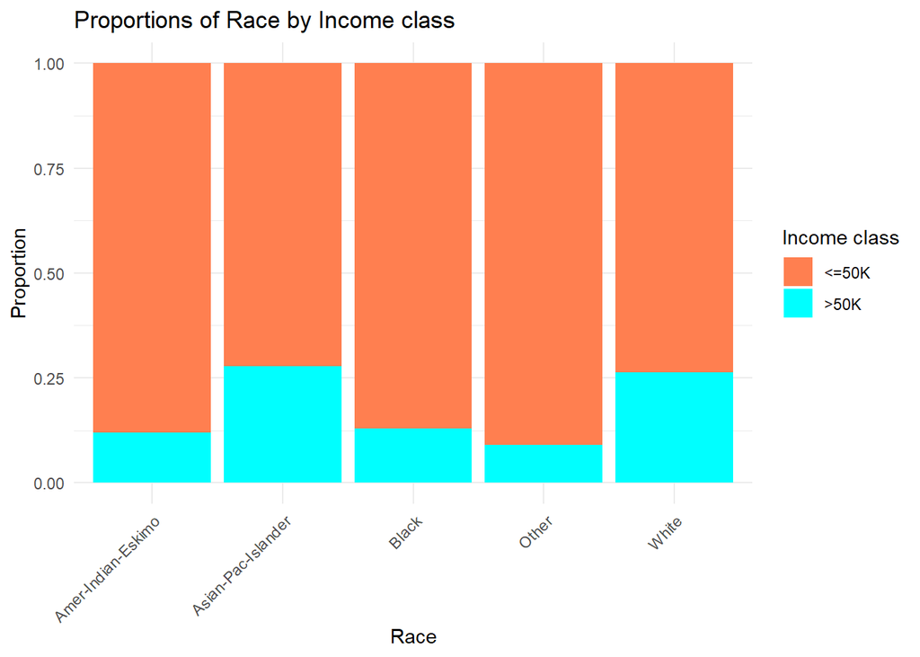

```r
# Race vs Income
ggplot(data_clean, aes(x = race, fill = factor(income))) +
  geom_bar(position = "fill") +
  labs(title = "Proportions of Race by Income class", x = "Race", y = "Proportion", fill = "Income class") +
  scale_fill_manual(values = c("coral", "cyan"), labels = c("<=50K", ">50K")) +
  theme_minimal() +
  theme(axis.text.x = element_text(angle = 45, hjust = 1))  # rotate x-axis labels
```

Race and income show some disparity, with certain racial groups earning more than others.

Out of interest, let’s look at the data of individuals working 98-99 hours per week:

```r
atleast_98hours <- data_clean |>
  filter(hours_per_week >= 98)
atleast_98hours
```

```
## # A tibble: 89 × 13
##      age workclass  education marital_status occupation relationship race  sex
##    <dbl> <chr>      <chr>     <chr>          <chr>      <chr>        <chr> <chr>
##  1    50 Self-emp-… Masters   Married-civ-s… Farming-f… Husband      White Male
##  2    37 Private    HS-grad   Married-civ-s… Craft-rep… Husband      White Male
##  3    25 Private    Masters   Married-civ-s… Farming-f… Not-in-fami… White Male
##  4    55 Self-emp-… Some-col… Married-civ-s… Farming-f… Husband      White Male
##  5    63 Self-emp-… HS-grad   Married-civ-s… Farming-f… Husband      White Male
##  6    37 Self-emp-… Doctorate Married-civ-s… Prof-spec… Husband      Black Male
##  7    35 Self-emp-… HS-grad   Married-civ-s… Farming-f… Husband      White Male
##  8    43 Self-emp-… Prof-sch… Married-civ-s… Prof-spec… Husband      Black Male
##  9    52 Self-emp-… HS-grad   Married-civ-s… Farming-f… Husband      White Male
## 10    43 Private    Assoc-voc Married-civ-s… Craft-rep… Husband      White Male
## # ℹ 79 more rows
## # ℹ 5 more variables: capital_gain <dbl>, capital_loss <dbl>,
## #   hours_per_week <dbl>, native_country <chr>, income <fct>
```

Based on this filtered data, the variables that stand out are `age` (generally middle-aged to older), `occupation`, and `marital_status`, `relationship`, `race`, `sex` i.e. white married husbands. Looking at the occupations by income:

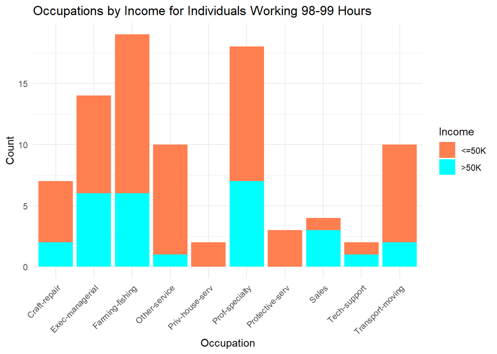

```r
# group variables
occupation_byincome_98 <- atleast_98hours |>
  group_by(occupation, income) |>
  count()

 # make column chart
occupation_byincome_98 |>
  ggplot(aes(x = occupation, y = n, fill = factor(income))) +  # Treat income as a factor for distinct colors
  geom_col() +
  theme_minimal() +
  theme(axis.text.x = element_text(angle = 45, hjust = 1)) +  # Rotate x-axis labels for readability
  labs(title = "Occupations by Income for Individuals Working 98-99 Hours",
       x = "Occupation", y = "Count", fill = "Income") +       # Adjust labels
  scale_fill_manual(values = c("coral", "cyan"),               # Use different colors for 0 and 1
                    labels = c("<=50K", ">50K"))
```

The variety of occupations have reduced and the proportion of individuals earning `>50K` is higher in this subset. While it’s possible that such long hours might result from data-entry errors, another plausible explanation could be that those in the >50K income bracket may hold jobs that require them to live on-site, earning income even during periods of rest. For the `<=50K` group, given that many of these individuals appear to be married men, the need to work long hours may be driven by the necessity to support their families. Though this raises interesting points, we will not delve deeper into these possibilities for now.

**Interaction terms:**

Including interaction terms could improve the predictive power of the model.

A possible interaction is between `hours_per_week` and `age`. As observed before, high earners tend to work more hours per week, particularly in their middle age, whereas, younger individuals are more likely to earn less, even if they work more hours.

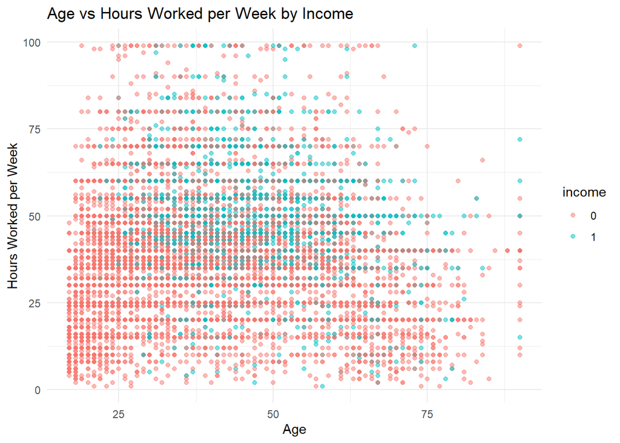

```r
data_clean %>% ggplot(., aes(x = age, y = hours_per_week, color = income)) +
  geom_point(alpha = 0.5) +
  labs(title = "Age vs Hours Worked per Week by Income", x = "Age", y = "Hours Worked per Week") +
  theme_minimal()
```

We can confirm whether or not this interaction is significant when we build the Logistic Regression model.